# Community Ecology Part 2: Beta diversity of Jellybelly Communities

Kristen DeAngelis

20 October, 2025

## Overview

This is the second part of two for practicing calculating measures of community diversity. In part 1, we explored the diversity metrics for a single community, or alpha diversity. In this part 2, we will explore the diversity metrics across mutliple communities, or beta diversity.

## Directions:

1. Change “author” on line 3 (above) to your name.
2. Complete as much of the assignment as possible during class; what you do not complete in class can be done on your own outside of class.
3. Use this handout as a guide; it contains a more complete description of data sets along with examples of proper scripting needed to carry out the exercise.
4. Be sure to **answer the questions** in this assignment document. Space for your answers is provided in this document and is indicated by the “>” character. If you need a second paragraph be sure to start the first line with “>”.
5. This activity is for practice and not points. If you would like feedback on your coding or answers, you may email it to Kristen (deangelis@umass.edu) or schedule a time to go over it together.

For our mock community, we will use a dataset from this paper: https://doi.org/10.1016/j.soilbio.2013.06.010. This is a real dataset measured using amplicon sequencing analysis for soil decomposition study.

We are working in Rstudio, and will work using markdown. R markdown files are denoted by the file extension .Rmd. Markdown is a simple but powerful formatting syntax for authoring HTML, PDF, and MS Word documents. For more details on how to get the most out of the Markdown language in R, see http://rmarkdown.rstudio.com.

In this Handout, we will perform the following tasks:

1. Set up our environment, read in files, and explore their contents & structure
2. Richness & diversity calculations
3. Ordination using NMDS & plotting
4. PCoA and joint plots

### 1a. Set up environment.

First we will set up our environment and load the libraries we’ll need. If you don’t have these installed already, use this command to install the packages:

- install.packages(“dplyr”) # for one install
- install.packages(c(“dplyr”,“vegan”,“plotrix”,“ggplot2”)) # for multiple packages

### 1b. Read in files.

```r
d = read.delim("kmd_test_set.txt", header=T)
rownames(d) <- d$Cluster

f = read.delim("kmd_test_second.txt", header=T)
```

For community ecology analyses, we ususall have two data matrixes: a primary matrix that is called a taxa table, and a secondary matrix of metadata. The primary matrix has one column for every sample, and one row for each taxon (or OTU, or as called in this dataset, cluster).

In this script, the primary matrix is called ‘d’ and the secondary matrix is called ‘f’.

Some of the data manipulations require a matrix, which contains the abundance values only with no metadata. Here, we will define ‘commu’ as only the part of the dataframe that contains the taxa abundances.

```r
comm <- d[,2:186]
```

### 1c. Explore the data.

This is a small dataset, but in microbial ecology, it is usual to have thousands to tens of thousands of taxa. These datasets are much to large to view directly, so they have to be explored.

Think of data exploration as a set of hypotheses that you test, in an iterative progression, with each experiment including expected results and evidence for whether you can accept or reject each hypothesis.

What kind of object is my data? What are the dimensions of my data? What are the variable names? What is the structure of my data object?

```r
class(d)
```

```
## [1] "data.frame"
```

```r
dim(d)    # 40852 211
```

```
## [1] 40852   211
```

```r
names(d)
```

```
##   [1] "Cluster"          "T1_L118"          "T1_L14"
##   [4] "T1_L148"          "T1_L168"          "T1_L192"
##   [7] "T1_L200"          "T1_L326"          "T1_L330"
##  [10] "T1_L34"           "T1_L352"          "T1_L358"
##  [13] "T1_L48"           "T1_L76"           "T1_L8"
##  [16] "T1_L96"           "T1_L98"           "T1_S118"
##  [19] "T1_S14"           "T1_S148"          "T1_S168"
##  [22] "T1_S192"          "T1_S326"          "T1_S330"
##  [25] "T1_S34"           "T1_S352"          "T1_S358"
##  [28] "T1_S48"           "T1_S76"           "T1_S8"
##  [31] "T2_L104"          "T2_L110"          "T2_L158"
##  [34] "T2_L178"          "T2_L184"          "T2_L2"
##  [37] "T2_L22"           "T2_L29"           "T2_L302"
##  [40] "T2_L338"          "T2_L346"          "T2_L356"
##  [43] "T2_L376"          "T2_L42"           "T2_L82"
```

[output cut: 56 more lines]

```r
head(d)   # displays the first six rows of the data
```

```
##             Cluster T1_L118 T1_L14 T1_L148 T1_L168 T1_L192 T1_L200 T1_L326
## Cluster1   Cluster1      91      9      21      32       7       1      74
## Cluster2   Cluster2       6     14       0       4       2       2       8
## Cluster3   Cluster3      15      7       1      15      15       8      12
## Cluster5   Cluster5      14      5       1       5       1       0       2
## Cluster7   Cluster7    1446     16     484     236     160      55    1313
## Cluster12 Cluster12      11     11       0       0       0       1       0
##           T1_L330 T1_L34 T1_L352 T1_L358 T1_L48 T1_L76 T1_L8 T1_L96 T1_L98
## Cluster1      875      6      77     146     26     68    12     45     69
## Cluster2        5     19       2       5     11      9     7      6     27
## Cluster3        9     10       4      13      6      8     5     16     33
## Cluster5       12     11       0       9      6     10     2     17     27
## Cluster7      334      9     771    1908      0    692    22    282    437
## Cluster12       1      5       1       2     10     10     3     15     35
##           T1_S118 T1_S14 T1_S148 T1_S168 T1_S192 T1_S326 T1_S330 T1_S34 T1_S352
## Cluster1        2      1      89      12      26       2      57    140     114
## Cluster2      349    142      52      64      28     204     140     36     419
## Cluster3      197     42     118      79      59     201     240     11     437
## Cluster5      276     57      49      39      14      74     121     16     162
## Cluster7        9      0       6       1       1       5       1      0       7
## Cluster12     267     43       7      21       4      62      48      3     180
##           T1_S358 T1_S48 T1_S76 T1_S8 T2_L104 T2_L110 T2_L158 T2_L178 T2_L184
## Cluster1       59    101      1   337      13      34       8       2       0
## Cluster2      383     83    229  1364      16       2       0       6       4
## Cluster3      484     58    209   264      11       9       3      25      24
## Cluster5      186     57    196   128      56       9       8       6       7
## Cluster7        1      0      0     4     321     613     275      10       1
## Cluster12     126     58    142   486       2       1       1       0       3
##           T2_L2 T2_L22 T2_L29 T2_L302 T2_L338 T2_L346 T2_L356 T2_L376 T2_L42
## Cluster1      5      0      0       1      83       8     267      83      1
## Cluster2      5      2     13      14      29     171     489      10     18
## Cluster3      5      5      8      17      26     161     272      22      6
## Cluster5      5      5     12       9      15      37     166      43     15
## Cluster7      0      3      5      68     278       0       0     271     63
## Cluster12     4      3      8      16       0      20      73       9     19
##           T2_L82 T2_L90 T2_S110 T2_S158 T2_S178 T2_S184 T2_S2 T2_S22 T2_S29
## Cluster1      73     15      10       0       1       1   995      2      6
## Cluster2       2      5     426      57      37      20   160     45     44
## Cluster3       3      4     230     115     123      81    88     22     50
## Cluster5       5     18     275      32      44      33    62     21     36
```

[output cut: 127 more lines]

```
## Cluster12    136298  Bacteria  Acidobacteria    Acidobacteriales
##                      Order           Family         Genus       Species
## Cluster1       Embryophyta     Tracheophyta Spermatophyta Magnoliophyta
## Cluster2         Ellin5121
## Cluster3  Bradyrhizobiales   Rhodoplanaceae
## Cluster5             CCD24         Ellin339
## Cluster7   Xanthomonadales Xanthomonadaceae   Xanthomonas
## Cluster12             BS61
##                   Subsp1              Subsp2       Subsp3        Subsp4  Subsp5
## Cluster1  eudicotyledons core eudicotyledons Saxifragales Saxifragaceae Mitella
## Cluster2
## Cluster3
## Cluster5
## Cluster7
## Cluster12
```

```r
str(d)    # returns a compact display of the data frame structure
```

```
## 'data.frame':    40852 obs. of  211 variables:
##  $ Cluster         : chr  "Cluster1" "Cluster2" "Cluster3" "Cluster5" ...
##  $ T1_L118         : int  91 6 15 14 1446 11 262 1199 43 45 ...
##  $ T1_L14          : int  9 14 7 5 16 11 52 156 11 21 ...
##  $ T1_L148         : int  21 0 1 1 484 0 7 446 1 20 ...
##  $ T1_L168         : int  32 4 15 5 236 0 35 753 18 14 ...
##  $ T1_L192         : int  7 2 15 1 160 0 39 705 8 6 ...
##  $ T1_L200         : int  1 2 8 0 55 1 85 386 7 3 ...
##  $ T1_L326         : int  74 8 12 2 1313 0 194 522 21 36 ...
##  $ T1_L330         : int  875 5 9 12 334 1 14 161 12 25 ...
##  $ T1_L34          : int  6 19 10 11 9 5 57 358 12 1 ...
##  $ T1_L352         : int  77 2 4 0 771 1 39 139 16 11 ...
##  $ T1_L358         : int  146 5 13 9 1908 2 36 1562 18 39 ...
##  $ T1_L48          : int  26 11 6 6 0 10 16 35 3 0 ...
##  $ T1_L76          : int  68 9 8 10 692 10 199 471 21 19 ...
```

[output cut: 86 more lines]

We are using many of the same data exploration techniques as we used in the alpha diversity section, but some are different. What are some differences and why can’t we use the same methods for alpha and beta diversity? >

Some of the outputs generated when we explore large datasets like this produce screen dumps that are very large, and the larger they are, the less helpful they are for seeing the data. Here are some additional ways to explore very large dataframes.

```r
d[1:5,1:7]
```

```
##           Cluster T1_L118 T1_L14 T1_L148 T1_L168 T1_L192 T1_L200
## Cluster1 Cluster1      91      9      21      32       7       1
## Cluster2 Cluster2       6     14       0       4       2       2
## Cluster3 Cluster3      15      7       1      15      15       8
## Cluster5 Cluster5      14      5       1       5       1       0
## Cluster7 Cluster7    1446     16     484     236     160      55
```

```r
head(d[, grepl("^T1", colnames(d))])
```

```
##           T1_L118 T1_L14 T1_L148 T1_L168 T1_L192 T1_L200 T1_L326 T1_L330 T1_L34
## Cluster1       91      9      21      32       7       1      74     875      6
## Cluster2        6     14       0       4       2       2       8       5     19
## Cluster3       15      7       1      15      15       8      12       9     10
## Cluster5       14      5       1       5       1       0       2      12     11
## Cluster7     1446     16     484     236     160      55    1313     334      9
## Cluster12      11     11       0       0       0       1       0       1      5
##           T1_L352 T1_L358 T1_L48 T1_L76 T1_L8 T1_L96 T1_L98 T1_S118 T1_S14
## Cluster1       77     146     26     68    12     45     69       2      1
## Cluster2        2       5     11      9     7      6     27     349    142
## Cluster3        4      13      6      8     5     16     33     197     42
## Cluster5        0       9      6     10     2     17     27     276     57
## Cluster7      771    1908      0    692    22    282    437       9      0
## Cluster12       1       2     10     10     3     15     35     267     43
##           T1_S148 T1_S168 T1_S192 T1_S326 T1_S330 T1_S34 T1_S352 T1_S358 T1_S48
## Cluster1       89      12      26       2      57    140     114      59    101
## Cluster2       52      64      28     204     140     36     419     383     83
## Cluster3      118      79      59     201     240     11     437     484     58
## Cluster5       49      39      14      74     121     16     162     186     57
## Cluster7        6       1       1       5       1      0       7       1      0
## Cluster12       7      21       4      62      48      3     180     126     58
##           T1_S76 T1_S8
## Cluster1       1   337
## Cluster2     229  1364
## Cluster3     209   264
## Cluster5     196   128
## Cluster7       0     4
## Cluster12    142   486
```

```r
comm[1:5,1:7]
```

```
##          T1_L118 T1_L14 T1_L148 T1_L168 T1_L192 T1_L200 T1_L326
## Cluster1      91      9      21      32       7       1      74
## Cluster2       6     14       0       4       2       2       8
## Cluster3      15      7       1      15      15       8      12
## Cluster5      14      5       1       5       1       0       2
## Cluster7    1446     16     484     236     160      55    1313
```

```r
head(comm[, grepl("^T1", colnames(comm))])
```

```
##           T1_L118 T1_L14 T1_L148 T1_L168 T1_L192 T1_L200 T1_L326 T1_L330 T1_L34
## Cluster1       91      9      21      32       7       1      74     875      6
## Cluster2        6     14       0       4       2       2       8       5     19
## Cluster3       15      7       1      15      15       8      12       9     10
## Cluster5       14      5       1       5       1       0       2      12     11
## Cluster7     1446     16     484     236     160      55    1313     334      9
## Cluster12      11     11       0       0       0       1       0       1      5
##           T1_L352 T1_L358 T1_L48 T1_L76 T1_L8 T1_L96 T1_L98 T1_S118 T1_S14
## Cluster1       77     146     26     68    12     45     69       2      1
## Cluster2        2       5     11      9     7      6     27     349    142
## Cluster3        4      13      6      8     5     16     33     197     42
## Cluster5        0       9      6     10     2     17     27     276     57
## Cluster7      771    1908      0    692    22    282    437       9      0
## Cluster12       1       2     10     10     3     15     35     267     43
##           T1_S148 T1_S168 T1_S192 T1_S326 T1_S330 T1_S34 T1_S352 T1_S358 T1_S48
## Cluster1       89      12      26       2      57    140     114      59    101
## Cluster2       52      64      28     204     140     36     419     383     83
## Cluster3      118      79      59     201     240     11     437     484     58
## Cluster5       49      39      14      74     121     16     162     186     57
## Cluster7        6       1       1       5       1      0       7       1      0
## Cluster12       7      21       4      62      48      3     180     126     58
##           T1_S76 T1_S8
## Cluster1       1   337
## Cluster2     229  1364
## Cluster3     209   264
## Cluster5     196   128
## Cluster7       0     4
## Cluster12    142   486
```

Now we can do the same kind of data exploration for the secondary matrix.

```r
class(f)
```

```
## [1] "data.frame"
```

```r
dim(f)    # 185 7
```

```
## [1] 185   8
```

```r
names(f)
```

```
## [1] "ID"        "DNA"       "type"      "T"         "weeks"     "site"
## [7] "elevation" "time"
```

```r
head(f)   # Display the first six rows of the data
```

```
##        ID   DNA type  T weeks site elevation time
## 1 T1_L118 204.2 Litt T1     1 Col2       750    1
## 2  T1_L14 137.3 Litt T1     1  SCF      1006    1
## 3 T1_L148 192.2 Litt T1     1 BisV       250    1
## 4 T1_L168 241.6 Litt T1     1 BisV       250    1
## 5 T1_L192 197.2 Litt T1     1 BisV       250    1
## 6 T1_L200 143.8 Litt T1     1 BisV       250    1
```

```r
str(f)
```

```
## 'data.frame':    185 obs. of  8 variables:
##  $ ID       : chr  "T1_L118" "T1_L14" "T1_L148" "T1_L168" ...
##  $ DNA      : num  204 137 192 242 197 ...
##  $ type     : chr  "Litt" "Litt" "Litt" "Litt" ...
##  $ T        : chr  "T1" "T1" "T1" "T1" ...
##  $ weeks    : int  1 1 1 1 1 1 1 1 1 1 ...
##  $ site     : chr  "Col2" "SCF" "BisV" "BisV" ...
##  $ elevation: int  750 1006 250 250 250 250 276 276 1006 276 ...
##  $ time     : int  1 1 1 1 1 1 1 1 1 1 ...
```

These are some checks for deciding if the data needs cleaning.

```r
any(is.na(comm))            # Are there any missing (NA) values?
```

```
## [1] FALSE
```

```r
sum(is.na(comm))            # How many missing values?
```

```
## [1] 0
```

```r
which(is.na(comm))          # Where are the missing values?
```

```
## integer(0)
```

We should also check for rows with all zeros, and remove them.

```r
zero.y <- which(rowSums(comm)==0)
comm.no0s <- comm[-zero.y,]

zero.x <- which(colSums(comm)==0) # none
```

```r
d %>% count(Taxonomy)
```

```
##    Taxonomy     n
## 1   Archaea   588
## 2  Bacteria 37873
## 3 Eukaryota  2391
```

```r
d %>% count(Taxonomy, Phylum)
```

```
##      Taxonomy
## 1     Archaea
## 2     Archaea
## 3     Archaea
## 4     Archaea
## 5     Archaea
## 6     Archaea
## 7     Archaea
## 8     Archaea
## 9     Archaea
## 10    Archaea
## 11    Archaea
## 12    Archaea
## 13    Archaea
## 14    Archaea
```

[output cut: 444 more lines]

```r
table.by.Phylum <- d[d$Taxonomy=="Eukaryota",] %>%
  group_by(Phylum) %>%
  mutate(group_size = n()) %>%
  ungroup() %>%
  mutate(Phylum = ifelse(group_size < 3, "Other", Phylum)) %>%
  count(Phylum)

table.by.Phylum
```

```
## # A tibble: 23 × 2
##    Phylum                 n
##    <chr>              <int>
##  1 Acanthamoebidae       19
##  2 Alveolata            262
##  3 Ancyromonadidae        3
##  4 Centroheliozoa         5
##  5 Cercozoa             313
##  6 Choanoflagellida       3
##  7 Cryptophyta            5
##  8 Euglenozoa            57
##  9 Fungi                831
## 10 Granuloreticulosea    23
## # ℹ 13 more rows
```

```r
print(table.by.Phylum, n = Inf)
```

```
## # A tibble: 23 × 2
##    Phylum                 n
##    <chr>              <int>
##  1 Acanthamoebidae       19
##  2 Alveolata            262
##  3 Ancyromonadidae        3
##  4 Centroheliozoa         5
##  5 Cercozoa             313
##  6 Choanoflagellida       3
##  7 Cryptophyta            5
##  8 Euglenozoa            57
##  9 Fungi                831
## 10 Granuloreticulosea    23
## 11 Haplosporidia          6
## 12 Haptophyceae           6
## 13 Heterolobosea          9
## 14 Ichthyosporea         33
## 15 Lobosea               51
## 16 Metazoa              416
## 17 Nucleariidae           6
## 18 Other                  9
## 19 Phalansterium          4
## 20 Rhodophyta             3
## 21 Telonema               3
## 22 Viridiplantae        207
## 23 stramenopiles        117
```

*** Challenge Below, we will calculate measures of diversity for the whole community, which includes the three domains of life. How might you expect them to behave differently across the experimental factors? Calculate diversity separately for Archaea, Bacteria, and Eukaryotes. >

If you wanted to explore metrics of diversity for the domains separately, you’d first need to make subsets for the three domains like this (remove the hashes ‘#’ to un-block the chunk): #`{r} d.a <- subset(d, Taxonomy == "Archaea") d.b <- subset(d, Taxonomy == "Bacteria") d.f <- subset(d, Taxonomy == "Eukaryota") #`

### 2. Richness & diversity calculations

Because richness and diversity are properties of single communities, and this dataset is a collection of 185 communities (variables, or columns in ‘comm’), we need to make calculations across all the rows. R is very good at matrix algebra; you may want to review this topic …

To calculate richness, first we need to convert abundance tables to presence-absence.

```r
d.pa = comm.no0s
threshold = 1
for(x in 1:length(d.pa)){
    d.pa[which(d.pa[,x]>=threshold),x] = 1
    d.pa[which(d.pa[,x] < threshold),x] = 0
}
```

Let’s explore this a bit to make sure it worked.

```r
d.pa[1:8,1:7]
```

```
##           T1_L118 T1_L14 T1_L148 T1_L168 T1_L192 T1_L200 T1_L326
## Cluster1        1      1       1       1       1       1       1
## Cluster2        1      1       0       1       1       1       1
## Cluster3        1      1       1       1       1       1       1
## Cluster5        1      1       1       1       1       0       1
## Cluster7        1      1       1       1       1       1       1
## Cluster12       1      1       0       0       0       1       0
## Cluster15       1      1       1       1       1       1       1
## Cluster18       1      1       1       1       1       1       1
```

```r
d.pa[40843:40850,1:7]
```

```
##               T1_L118 T1_L14 T1_L148 T1_L168 T1_L192 T1_L200 T1_L326
## Cluster387752       0      0       0       0       0       0       0
## Cluster224154       0      0       0       0       0       0       0
## Cluster251220       0      0       0       0       0       0       0
## Cluster325430       0      0       0       0       0       0       0
## Cluster37035        0      0       0       0       0       0       0
## Cluster17600        0      0       0       0       0       0       0
## Cluster27149        0      0       0       0       0       0       0
## Cluster423730       0      0       0       0       0       0       0
```

Why do you think there are mostly 1s for the lower-numbered clusters, and mostly zeros for the higher-numbered clusters? >

Now we can use the presence/absence table to calculate observed richness. The adds the total for all the columns (variables, or sites), and then performes some exploratory analysis.

```r
richness = sapply(d.pa,sum)
head(richness)
```

```
## T1_L118  T1_L14 T1_L148 T1_L168 T1_L192 T1_L200
##     547     456     349     602     543     580
```

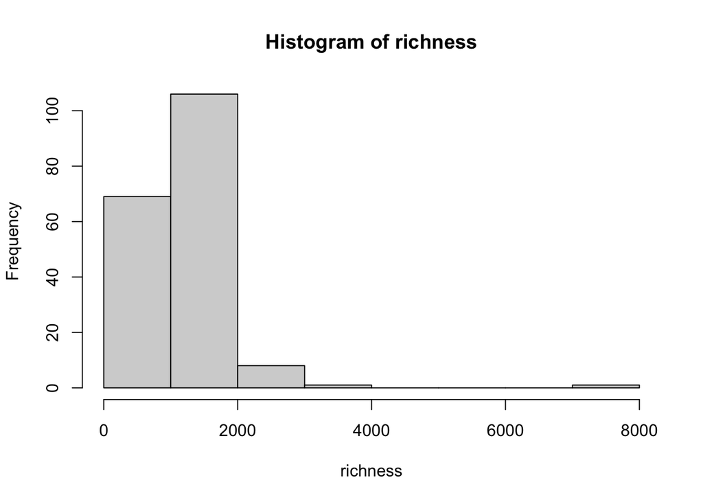

```r
hist(richness)
```

```r
summary(richness)
```

```
##    Min. 1st Qu.  Median    Mean 3rd Qu.    Max.
##     318     805    1172    1232    1476    7532
```

It looks there are two outlier samples with a very high observed richness. We can use which() to find it. this will return the item number (not the richness value). The second line of code subsets the total.richness vector to show the value of that index in the vector.

```r
which(richness > 3000)
```

```
##   T1_S8 T4_L193
##      29     101
```

```r
richness[c(29,101)] # 7532, 3694
```

```
##   T1_S8 T4_L193
##    7532    3694
```

```r
d1 <- d[, -c(30,102)]
f1 <- f[-c(29,101),]

d.pa1 = d1[,2:184]
threshold = 1
for(x in 1:length(d.pa1)){
    d.pa1[which(d.pa1[,x]>=threshold),x] = 1
    d.pa1[which(d.pa1[,x] < threshold),x] = 0
}

richness = sapply(d.pa1,sum)
head(richness)
```

```
## T1_L118  T1_L14 T1_L148 T1_L168 T1_L192 T1_L200
##     547     456     349     602     543     580
```

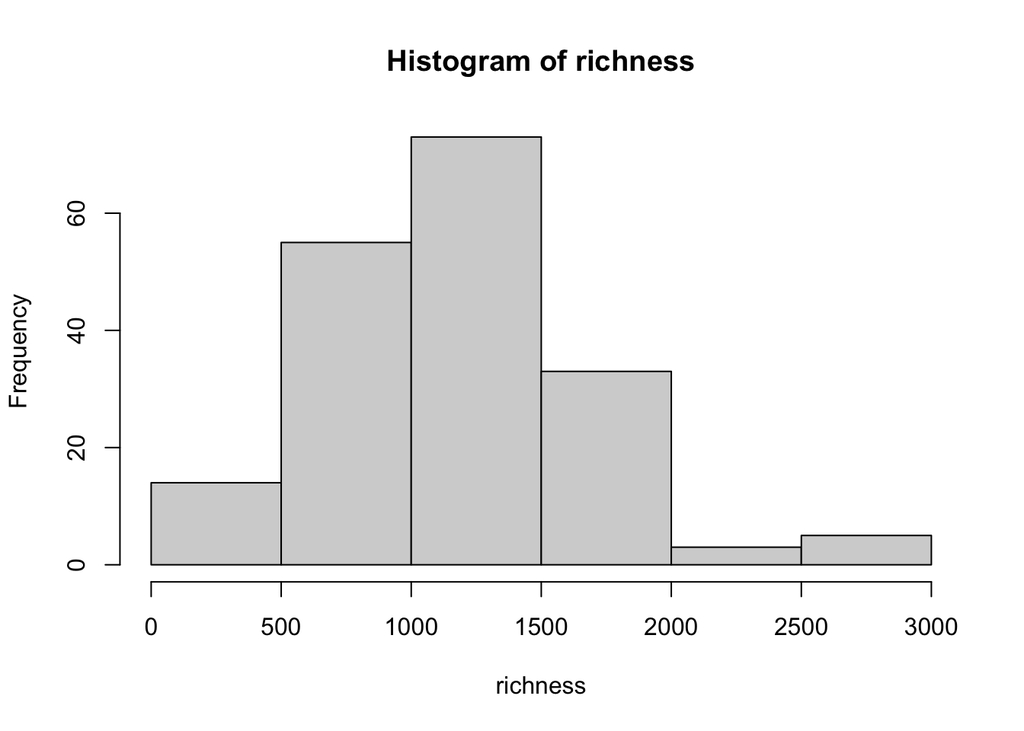

```r
hist(richness)
```

```r
summary(richness)
```

```
##    Min. 1st Qu.  Median    Mean 3rd Qu.    Max.
##     318     805    1162    1185    1472    2999
```

This line adds the calculation to the secondary matrix. This is so we can use the data on the samples (variables, or sites) to peform statistics.

```r
rownames(f1) <- f1$ID
f1$richness <- richness[rownames(f1)]
head(f1)
```

```
##              ID   DNA type  T weeks site elevation time richness
## T1_L118 T1_L118 204.2 Litt T1     1 Col2       750    1      547
## T1_L14   T1_L14 137.3 Litt T1     1  SCF      1006    1      456
## T1_L148 T1_L148 192.2 Litt T1     1 BisV       250    1      349
## T1_L168 T1_L168 241.6 Litt T1     1 BisV       250    1      602
## T1_L192 T1_L192 197.2 Litt T1     1 BisV       250    1      543
## T1_L200 T1_L200 143.8 Litt T1     1 BisV       250    1      580
```

Now that we have observed richness calculated for all the sites, we can perform statistics on richness. In this case we want to know if richness varies by site, and if it varies by site if we separate soil samples “Soil” from litter samples “Litt”.

```r
summary(aov(richness ~ site, data=f1)) # n.s.
```

```
##              Df   Sum Sq Mean Sq F value Pr(>F)
## site          3  1373334  457778   1.759  0.157
## Residuals   179 46581894  260234
```

```r
summary(aov(richness ~ site, data=f1[f1$type=="Soil",])) # p = 0.0386 *
```

```
##             Df   Sum Sq Mean Sq F value Pr(>F)
## site         3  1944793  648264    2.92 0.0386 *
## Residuals   86 19090637  221984
## ---
## Signif. codes:  0 '***' 0.001 '**' 0.01 '*' 0.05 '.' 0.1 ' ' 1
```

```r
summary(aov(richness ~ site, data=f1[f1$type=="Litt",])) # n.s.
```

```
##             Df   Sum Sq Mean Sq F value Pr(>F)
## site         3   143191   47730   0.163  0.921
## Residuals   89 25988124  292001
```

Because there was a difference in total richness by soil type, we will keep them separate and explore if there is a variation in richness over time (“T”). This treats time as a discreet variable, but in some cases it will make more sense to treat time as a continuous variable.

```r
summary(aov(richness ~ T, data=f1[f1$type=="Soil",])) # ***
```

```
##             Df   Sum Sq Mean Sq F value  Pr(>F)
## T            5  5398063 1079613   5.799 0.00012 ***
## Residuals   84 15637368  186159
## ---
## Signif. codes:  0 '***' 0.001 '**' 0.01 '*' 0.05 '.' 0.1 ' ' 1
```

```r
summary(aov(richness ~ T, data=f1[f1$type=="Litt",])) # ***
```

```
##             Df   Sum Sq Mean Sq F value Pr(>F)
## T            5 16792978 3358596   31.29 <2e-16 ***
## Residuals   87  9338337  107337
## ---
## Signif. codes:  0 '***' 0.001 '**' 0.01 '*' 0.05 '.' 0.1 ' ' 1
```

```r
TukeyHSD(aov(richness ~ T, data=f1[f1$type=="Soil",]))
```

```
##   Tukey multiple comparisons of means
##     95% family-wise confidence level
##
## Fit: aov(formula = richness ~ T, data = f1[f1$type == "Soil", ])
##
## $T
##           diff        lwr       upr     p adj
## T2-T1  28.9000 -458.46734  516.2673 0.9999778
## T3-T1 232.0333 -255.33400  719.4007 0.7337267
## T4-T1 600.7500  120.19932 1081.3007 0.0059507
## T5-T1 536.8125   56.26182 1017.3632 0.0194959
## T6-T1 545.7500   65.19932 1026.3007 0.0166333
## T3-T2 203.1333 -256.36100  662.6277 0.7900219
## T4-T2 571.8500  119.59225 1024.1077 0.0052029
## T5-T2 507.9125   55.65475  960.1702 0.0185300
## T6-T2 516.8500   64.59225  969.1077 0.0156388
## T4-T3 368.7167  -83.54108  820.9744 0.1759738
## T5-T3 304.7792 -147.47858  757.0369 0.3707546
## T6-T3 313.7167 -138.54108  765.9744 0.3382449
## T5-T4 -63.9375 -508.84097  380.9660 0.9982919
## T6-T4 -55.0000 -499.90347  389.9035 0.9991738
## T6-T5   8.9375 -435.96597  453.8410 0.9999999
```

```r
TukeyHSD(aov(richness ~ T, data=f1[f1$type=="Litt",]))
```

```
##   Tukey multiple comparisons of means
##     95% family-wise confidence level
##
## Fit: aov(formula = richness ~ T, data = f1[f1$type == "Litt", ])
##
## $T
##             diff        lwr        upr     p adj
## T2-T1  249.62500  -87.93489  587.18489 0.2695861
## T3-T1  554.00000  216.44011  891.55989 0.0001002
## T4-T1 1242.65417  899.51440 1585.79394 0.0000000
## T5-T1  868.31250  530.75261 1205.87239 0.0000000
## T6-T1  956.97321  607.56553 1306.38090 0.0000000
## T3-T2  304.37500  -33.18489  641.93489 0.1015056
## T4-T2  993.02917  649.88940 1336.16894 0.0000000
## T5-T2  618.68750  281.12761  956.24739 0.0000107
## T6-T2  707.34821  357.94053 1056.75590 0.0000010
## T4-T3  688.65417  345.51440 1031.79394 0.0000013
## T5-T3  314.31250  -23.24739  651.87239 0.0828220
## T6-T3  402.97321   53.56553  752.38090 0.0142339
## T5-T4 -374.34167 -717.48144  -31.20190 0.0242335
## T6-T4 -285.68095 -640.48224   69.12033 0.1871337
## T6-T5   88.66071 -260.74697  438.06840 0.9763937
```

```r
d.pa1$Cluster <- rownames(d.pa1)
d.pa2 <- cbind(d.pa1, d1[,185:209])
#d.pa2 <- merge(d.pa1, d1[,185:209])

summary(aov(richness ~ T, data=f1[f1$type=="Soil",])) # ***
```

```
##             Df   Sum Sq Mean Sq F value  Pr(>F)
## T            5  5398063 1079613   5.799 0.00012 ***
## Residuals   84 15637368  186159
## ---
## Signif. codes:  0 '***' 0.001 '**' 0.01 '*' 0.05 '.' 0.1 ' ' 1
```

```r
summary(aov(richness ~ T, data=f1[f1$type=="Litt",])) # ***
```

```
##             Df   Sum Sq Mean Sq F value Pr(>F)
## T            5 16792978 3358596   31.29 <2e-16 ***
## Residuals   87  9338337  107337
## ---
## Signif. codes:  0 '***' 0.001 '**' 0.01 '*' 0.05 '.' 0.1 ' ' 1
```

```r
TukeyHSD(aov(richness ~ T, data=f1[f1$type=="Soil",]))
```

```
##   Tukey multiple comparisons of means
##     95% family-wise confidence level
##
## Fit: aov(formula = richness ~ T, data = f1[f1$type == "Soil", ])
##
## $T
##           diff        lwr       upr     p adj
## T2-T1  28.9000 -458.46734  516.2673 0.9999778
## T3-T1 232.0333 -255.33400  719.4007 0.7337267
## T4-T1 600.7500  120.19932 1081.3007 0.0059507
## T5-T1 536.8125   56.26182 1017.3632 0.0194959
## T6-T1 545.7500   65.19932 1026.3007 0.0166333
## T3-T2 203.1333 -256.36100  662.6277 0.7900219
## T4-T2 571.8500  119.59225 1024.1077 0.0052029
## T5-T2 507.9125   55.65475  960.1702 0.0185300
## T6-T2 516.8500   64.59225  969.1077 0.0156388
## T4-T3 368.7167  -83.54108  820.9744 0.1759738
## T5-T3 304.7792 -147.47858  757.0369 0.3707546
## T6-T3 313.7167 -138.54108  765.9744 0.3382449
## T5-T4 -63.9375 -508.84097  380.9660 0.9982919
## T6-T4 -55.0000 -499.90347  389.9035 0.9991738
## T6-T5   8.9375 -435.96597  453.8410 0.9999999
```